# Sentiment Analysis of Political Social Media Posts using SVMs

### Andrew Morgan

Sentiment analysis is a classical, popular classification task where the sentiment (e.g. positive, negative, neutral) of pieces of text is classified using machine learning. While state-of-the-art sentiment analysis experiments usually involve transformers (LLMs), I'd like to take a look at the performance of a traditional machine learning algorithm: the support vector machine. The task at hand is the classification of partisanship in social media posts from politicians (with two label classes: "partisan" and "neutral"). The goal is to train a model that is able to differentiate between text that is partisan and text that isn't; in other words, the model should develop an "understanding" of what makes certain language partisan. Some online spaces like Twitter/X seem to have grown more political in recent years, which is why this task interested me and why classifying partisanship specifically is relevant. Also, I found the challenge of trying to distill what makes text "partisan" a fascinating and layered challenge.

I will be using Figure Eight/Appen's Political Social Media Posts dataset from Kaggle, which was annotated by a number of contributors and appears reputable and well-maintained: https://www.kaggle.com/datasets/crowdflower/political-social-media-posts?resource=download. The data was provided by Appen (https://www.appen.com/), an established company (they claim 25+ years of industry experience) that provides annotated datasets for training AI models, among other things. Data quality is especially important in a domain as subjective as language.

Because the only obvious feature in this case is the text itself, I'll also be using a word vectorizer, or in other words, an algorithm that converts strings of text into feature vectors that encapsulate the meaning of the text. In line with my examination of traditional machine learning algorithms, I'll be looking at a traditional text vectorization method offered by scikit-learn: word count (also known as "bag-of-words") vectorization.

## Pre-processing

The preprocessing will cover a brief introduction to the raw dataset itself, and the feature engineering that will lead to the construction of the training and testing sets. As stated in the introduction, I will be using count vectorization to transform my raw text into useable feature vectors.

First, let's load in the data:

```python
import pandas as pd

data = pd.read_csv("proj_2_data/political_social_media.csv", encoding_errors="replace")
data.head()
```

|  | _unit_id | _golden | _unit_state | _trusted_judgments | _last_judgment_at | audience | audience:confidence | bias | bias:confidence | message | ... | orig__golden | audience_gold | bias_gold | bioid | embed | id | label | message_gold | source | text |
| --- | --- | --- | --- | --- | --- | --- | --- | --- | --- | --- | --- | --- | --- | --- | --- | --- | --- | --- | --- | --- | --- |
| 0 | 766192484 | False | finalized | 1 | 8/4/15 21:17 | national | 1.0 | partisan | 1.0 | policy | ... | NaN | NaN | NaN | R000596 | <blockquote class="twitter-tweet" width="450">... | 3.83249E+17 | From: Trey Radel (Representative from Florida) | NaN | twitter | RT @nowthisnews: Rep. Trey Radel (R- #FL) slam... |
| 1 | 766192485 | False | finalized | 1 | 8/4/15 21:20 | national | 1.0 | partisan | 1.0 | attack | ... | NaN | NaN | NaN | M000355 | <blockquote class="twitter-tweet" width="450">... | 3.11208E+17 | From: Mitch McConnell (Senator from Kentucky) | NaN | twitter | VIDEO - #Obamacare: Full of Higher Costs and ... |
| 2 | 766192486 | False | finalized | 1 | 8/4/15 21:14 | national | 1.0 | neutral | 1.0 | support | ... | NaN | NaN | NaN | S001180 | <blockquote class="twitter-tweet" width="450">... | 3.39069E+17 | From: Kurt Schrader (Representative from Oregon) | NaN | twitter | Please join me today in remembering our fallen... |
| 3 | 766192487 | False | finalized | 1 | 8/4/15 21:08 | national | 1.0 | neutral | 1.0 | policy | ... | NaN | NaN | NaN | C000880 | <blockquote class="twitter-tweet" width="450">... | 2.98528E+17 | From: Michael Crapo (Senator from Idaho) | NaN | twitter | RT @SenatorLeahy: 1st step toward Senate debat... |
| 4 | 766192488 | False | finalized | 1 | 8/4/15 21:26 | national | 1.0 | partisan | 1.0 | policy | ... | NaN | NaN | NaN | U000038 | <blockquote class="twitter-tweet" width="450">... | 4.07643E+17 | From: Mark Udall (Senator from Colorado) | NaN | twitter | .@amazon delivery #drones show need to update ... |

5 rows × 21 columns

For our purpose of classifying the partisan sentiment of text, we're interested in only the text and bias columns (though it would be interesting to do multi-class classification of the message of the text as future work!). Let's grab those columns:

```python
data = data[["bias", "text"]]
data.head()
```

|  | bias | text |
| --- | --- | --- |
| 0 | partisan | RT @nowthisnews: Rep. Trey Radel (R- #FL) slam... |
| 1 | partisan | VIDEO - #Obamacare: Full of Higher Costs and ... |
| 2 | neutral | Please join me today in remembering our fallen... |
| 3 | neutral | RT @SenatorLeahy: 1st step toward Senate debat... |
| 4 | partisan | .@amazon delivery #drones show need to update ... |

Next, before we organize our data into X (example) and y (label) pairs, we need to encode our examples and labels. Encoding the bias (our label) is easier, so let's do that using scikit-learn's LabelEncoder, which simply encodes our binary labels "neutral" and "partisan" to classes 0 and 1:

```python
from sklearn.preprocessing import LabelEncoder

le = LabelEncoder()
labels_unenc = data["bias"].to_numpy()
labels_enc = le.fit_transform(labels_unenc)
labels_enc
```

```
array([1, 1, 0, ..., 0, 0, 0])
```

Now we have our labels encoded in a numpy array. Next, let's encode our text. While it only occupies one column, the text actually contains several features; that is, qualities of the text that help our model learn what makes the text partisan or neutral. What we need is a ___representation___ of the text as a vector of features. While there are endlessly complex ways of doing this (as language is endlessly complex), such as word2vec, let's use a simpler, traditional method, which is to represent the text as a collection of words and their respective counts in the text.

Before I encode the text, a quick word on *stop words*, which are words that provide little information about the text and are therefore excluded from the text representation. According to their own documentation, scikit-learn's list of stop words is unreliable; instead, I will use Natural Language Toolkit (NLTK)'s, another popular machine learning library designed particularly for natural language processing, list of stop words.

First I'll get the stop words:

```python
import nltk
from nltk.corpus import stopwords

# Reference: https://www.geeksforgeeks.org/removing-stop-words-nltk-python/
nltk.download("stopwords")
stopwords = stopwords.words("english")
stopwords.extend(["http", "co", "amp", "www"])  # since our corpus contains many texts with URLs (mostly .co URLs),
# it's smart to remove common URL keywords that could pollute our data
stopwords[:10]
```

```
['a', 'about', 'above', 'after', 'again', 'against', 'ain', 'all', 'am', 'an']
```

Now I'll use scikit-learn's CountVectorizer to encode the text:

```python
from sklearn.feature_extraction.text import CountVectorizer

cv = CountVectorizer(stop_words=stopwords)
text_unenc = data["text"].to_numpy()
text_enc = cv.fit_transform(text_unenc)  # Encodes each piece of text to a vector of word occurrences
features = cv.get_feature_names_out()  # prints all words occurring in the entire corpus of text
features
```

```
array(['00', '000', '000th', ..., 'zxm76lhmt3', 'zy1gf0fuss',
       'zzydwjlic0'], dtype=object)
```

Looks like some less useful terms (looks like perhaps unique parts of URLs?) are being included in the count...

```python
len(features)
```

```
17858
```

That's a lot of features! Lets narrow it down to the top 1000 words, to as best as we can remove the superfluous features:

```python
cv_fixed = CountVectorizer(stop_words=stopwords, max_features=1000)
text_enc = cv_fixed.fit_transform(text_unenc)
features = cv_fixed.get_feature_names_out()
features[:100]
```

```
array(['00', '000', '05', '10', '100', '11', '12', '13', '14', '15', '17',
       '1st', '20', '2012', '2013', '2014', '2015', '21', '22', '25',
       '28', '30', '3rd', '40', '4th', '50', 'able', 'abuse', 'aca',
       'academy', 'access', 'according', 'accountability', 'accountable',
       'across', 'act', 'action', 'actions', 'additional', 'address',
       'administration', 'advocate', 'affairs', 'affected', 'affordable',
       'afghanistan', 'afternoon', 'agencies', 'agency', 'ago', 'agree',
       'agreement', 'agriculture', 'ahead', 'aid', 'air', 'al', 'alaska',
       'allow', 'along', 'already', 'also', 'always', 'amendment',
       'amendments', 'america', 'american', 'americans', 'among',
       'anniversary', 'announce', 'announced', 'annual', 'another',
       'answer', 'approach', 'appropriations', 'april', 'area', 'areas',
       'arizona', 'army', 'around', 'art', 'article', 'ask', 'asked',
       'assistance', 'association', 'attack', 'attacks', 'attend',
       'attended', 'authorization', 'available', 'average', 'award',
       'awareness', 'away', 'back'], dtype=object)
```

Better. It looks like there are still some terms (in particular, the numbers), that are probably not as useful, but this makes a lot more sense to train on. Finally, let's create our splits. I'll use a standard 80/20 training and testing split:

```python
import numpy as np
from sklearn.model_selection import train_test_split

X = np.array(text_enc.toarray())  # text_enc was returned as a SciPy matrix data type, convert to NumPy array
y = labels_enc

print(len(X), len(y))

X_train, X_test, y_train, y_test = train_test_split(X, y, train_size=0.8, random_state=5)

# also creating a version of the split set that isn't encoded, so later we can look at the text associated with the model's classifications.
# using the same random_state (seed) for reproducibility
X_unenc_train, X_unenc_test, y_unenc_train, y_unenc_test = train_test_split(text_unenc, labels_unenc, train_size=0.8, random_state=5)

len(X_train), len(y_train), len(X_test), len(y_test)
```

```
5000 5000
```

```
(4000, 4000, 1000, 1000)
```

```python
X_test
```

```
array([[0, 0, 0, ..., 0, 0, 0],
       [0, 0, 0, ..., 0, 0, 0],
       [0, 0, 0, ..., 0, 0, 0],
       ...,
       [0, 0, 0, ..., 0, 0, 0],
       [0, 0, 0, ..., 0, 0, 0],
       [0, 0, 0, ..., 0, 0, 0]], dtype=int64)
```

## Feature Visualization

Let's help motivate our intent by looking at some visualizations of our 1000 text features. First, to get an idea of what terms most characterize our data, I'll get the most commonly occurring terms:

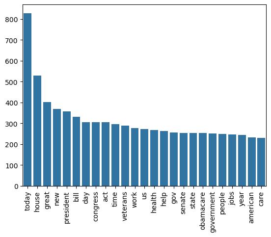

```python
import seaborn as sns
from matplotlib import pyplot as plt

feat_counts = {}

# i = feature index in each vector
for i, feat in zip(range(0, len(features)), features):
    feat_counts.update({feat: 0})
    for vec in X:
        feat_counts[feat] += vec[i]

counts = pd.Series(feat_counts.values(), index=feat_counts.keys())

counts = counts.sort_values(ascending=False)

counts = counts[:25]

plt.xticks(rotation=90)

sns.barplot(data=counts)
```

Now that we have our data preprocessed and prepared, let's get to training our model, the support vector machine (SVM).

## Training a SVM / SVM Overview

I plan to use SVMs (support vector machines) because they adapt to high-dimensional scenarios well (because of kernels, discussed below). SVMs rely on finding the optimal hyperplane that separates the given examples (in our case, in a 1000-dimensional space, as we have 1000-dimensional feature vectors) such that the margin between the two label classes in the space is maximized. Out-of-the-box SVMs only function with linearly separable data, so a so-called "kernel function" is used to transform the features to a higher dimensional space where linear separability may exist and a hyperplane can be found. Of course, unless we are extremely lucky, our text feature space will not be linearly separable, so we'll use a kernel function to allow for the SVM to find an optimal non-linear hyperplane. Scikit-learn uses the radial basis function as the default kernel function, which transforms example data to infinite dimensions (but still finds the hyperplane in our 1000 dimensions) and makes the most sense for our high-dimensional task.

One potential negative in using SVMs is that they introduce some bias when training on imbalanced datasets (according to https://towardsdatascience.com/when-do-support-vector-machines-fail-3f23295ebef2/). I've attempted to counteract this by balancing the class weights when I initialize the SVM, which pre-empts the bias towards the minority class (partisan) by weighting partisan more than neutral.

```python
from sklearn.svm import SVC

classifier = SVC(probability=True, class_weight="balanced")  # RBF kernel by default.
# since our label classes are not balanced ("neutral" is a lot more common than "partisan"), balance the label class weights

classifier.fit(X_train, y_train)
y_pred = classifier.predict(X_test)
y_pred
```

```
array([0, 0, 0, 0, 0, 0, 1, 0, 0, 1, 0, 0, 0, 1, 1, 0, 0, 1, 0, 0, 0, 1,
       0, 0, 0, 1, 0, 0, 0, 0, 0, 0, 0, 0, 0, 0, 0, 1, 0, 0, 0, 0, 1, 0,
       1, 1, 0, 0, 0, 0, 1, 1, 1, 0, 0, 0, 1, 0, 1, 1, 1, 1, 1, 1, 1, 0,
       1, 0, 0, 1, 1, 0, 1, 0, 0, 0, 0, 0, 0, 1, 0, 1, 0, 1, 1, 0, 1, 0,
       0, 0, 0, 0, 0, 0, 0, 0, 1, 0, 0, 1, 1, 0, 0, 0, 0, 0, 1, 0, 0, 0,
       0, 0, 0, 1, 1, 1, 0, 0, 0, 0, 0, 0, 0, 0, 0, 1, 0, 0, 0, 1, 0, 0,
       0, 0, 0, 1, 0, 1, 1, 0, 0, 0, 0, 1, 0, 0, 0, 0, 0, 0, 0, 0, 0, 0,
       0, 0, 0, 1, 0, 1, 0, 0, 0, 0, 0, 0, 1, 0, 0, 0, 0, 0, 0, 1, 0, 0,
       1, 0, 0, 0, 0, 0, 0, 0, 0, 0, 0, 0, 0, 1, 0, 0, 0, 0, 1, 0, 0, 0,
       0, 1, 1, 1, 0, 1, 0, 0, 0, 1, 1, 0, 0, 0, 1, 0, 1, 0, 0, 1, 1, 0,
       0, 0, 0, 0, 1, 0, 0, 0, 0, 0, 0, 1, 1, 0, 1, 0, 1, 1, 0, 0, 0, 0,
       0, 0, 0, 1, 0, 0, 1, 0, 0, 1, 0, 0, 1, 0, 0, 0, 0, 0, 0, 0, 0, 1,
       0, 1, 0, 0, 0, 0, 0, 0, 1, 1, 1, 0, 0, 1, 1, 1, 1, 0, 0, 0, 0, 0,
       0, 1, 0, 1, 1, 0, 0, 0, 1, 1, 1, 0, 1, 0, 0, 1, 0, 0, 0, 0, 0, 0,
       0, 0, 0, 1, 0, 0, 1, 0, 1, 1, 1, 0, 1, 0, 0, 0, 0, 0, 0, 1, 0, 1,
```

[output cut: 31 more lines]

```python
probs = classifier.predict_proba(X_test)
probs
```

```
array([[0.77172717, 0.22827283],
       [0.96234083, 0.03765917],
       [0.80106787, 0.19893213],
       ...,
       [0.59666344, 0.40333656],
       [0.7422408 , 0.2577592 ],
       [0.86034844, 0.13965156]])
```

## Evaluation and Model Inspection

Now that we have the predictions, we can compute some metrics against our y_test data. Here, I'll use accuracy as well as precision, recall, and F1 score, which paint a fuller story of the model's performance than accuracy alone.

Recall is the rate at which the model correctly made a positive prediction against all actual positive labels in the test dataset, while precision is the rate at which the model correctly made a positive prediction against all actual correct and incorrect positive labels. The F1 score roughly combines the two into one metric. First, to visualize the model's performance, I'll generate a confusion matrix, which documents all of the true positive, false positive, true negative, and false negative predictions made by the model.

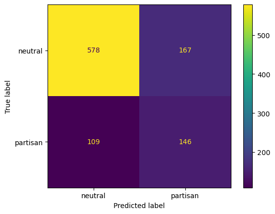

```python
from sklearn.metrics import confusion_matrix, ConfusionMatrixDisplay, classification_report

labels = ["neutral", "partisan"]

matrix = confusion_matrix(y_test, y_pred)
display = ConfusionMatrixDisplay(matrix, display_labels=labels)
display.plot()
plt.show()
```

```python
report = classification_report(y_test, y_pred, target_names=labels, output_dict=True)
report
```

```
{'neutral': {'precision': 0.8413391557496361,
  'recall': 0.7758389261744967,
  'f1-score': 0.8072625698324022,
  'support': 745.0},
 'partisan': {'precision': 0.46645367412140576,
  'recall': 0.5725490196078431,
  'f1-score': 0.5140845070422535,
  'support': 255.0},
 'accuracy': 0.724,
 'macro avg': {'precision': 0.653896414935521,
  'recall': 0.6741939728911699,
  'f1-score': 0.6606735384373279,
  'support': 1000.0},
 'weighted avg': {'precision': 0.7457433579344374,
  'recall': 0.724,
  'f1-score': 0.7325021638209144,
  'support': 1000.0}}
```

```python
classifier.score(X_test, y_test)
```

```
0.724
```

The performance appears fairly mediocre, though certainly much better than random guessing. The model appears to have had difficulty capturing the meaning of "partisan" as defined by the data. There is a slight skew towards over-predicting text as partisan (i.e., labeling partisan for neutral text), considering the lower precision for the partisan label. The precise reason for these struggles is difficult to interpret, given the high complexity of language, but I would wager that it has to do with the count vectorization process not preserving all of the semantic information of what made the text neutral or partisan (in other words, a loss of contextualization).

Let's manually look at some misclassified examples as well as some correct "partisan" classifications to try and get a better idea of why the model is missing this way. Note that I balanced the class weights when I initialized the model because of the class imbalance in the dataset, so there is a (intentional) bias toward predicting that the text is partisan.

```python
print("### False Negatives (up to data point 40) ###")
for i, label in enumerate(y_pred[:40]):
    if label == 0 and y_test[i] == 1:
        print("_____________ \n")
        print(f"Text: {X_unenc_test[i]} \n")
        print(f"Actual label: {y_unenc_test[i]}")
        print(f"Predicted label: {labels[label]} \n")
        print(f"Probability of neutral/partisan: {probs[i]}\n")

print("### False Positives (up to data point 150) ###")
for i, label in enumerate(y_pred[:150]):
    if label == 1 and y_test[i] == 0:
        print("_____________ \n")
        print(f"Text: {X_unenc_test[i]} \n")
        print(f"Actual label: {y_unenc_test[i]}")
        print(f"Predicted label: {labels[label]} \n")
        print(f"Probability of neutral/partisan: {probs[i]}\n")

print("### True Positives (up to data point 70) ###")
for i, label in enumerate(y_pred[:70]):
    if label == 1 and y_test[i] == 1:
        print("_____________ \n")
        print(f"Text: {X_unenc_test[i]} \n")
        print(f"Actual label: {y_unenc_test[i]}")
        print(f"Predicted label: {labels[label]}\n")
        print(f"Probability of neutral/partisan: {probs[i]}\n")
```

```
### False Negatives (up to data point 40) ###
_____________

Text: Remember Bill? He and his friends are stuck on @SenatorReid's desk. #4jobs http://t.co/0DCNU1R3G7

Actual label: partisan
Predicted label: neutral

Probability of neutral/partisan: [0.77172717 0.22827283]

_____________

Text: This morning I joined Democratic Whip Steny Hoyer at a press conference to highlight the House Democrats�۪ focus on creating jobs through our Make it in America agenda.  Meanwhile, Senate Republicans spent the morning blocking my legislation���the #BringJobsHome Act���that will help bring high…

Actual label: partisan
Predicted label: neutral

Probability of neutral/partisan: [0.682594 0.317406]

_____________

Text: There are less than 50 days until the Health Care Marketplaces Exchanges open for enrollment. The changes already in place have proven to be a huge success. Health premiums are rising at the slowest rate in decades, insurers can no longer deny coverage to the millions of children with preexist…

Actual label: partisan
Predicted label: neutral

Probability of neutral/partisan: [0.74178781 0.25821219]

_____________

Text: Great to be at @nnedv breakfast to support efforts to end domestic violence http://t.co/cPdvu76fY6

Actual label: partisan
Predicted label: neutral

Probability of neutral/partisan: [0.91213577 0.08786423]

### False Positives (up to data point 150) ###
_____________

```

[output cut: 289 more lines]

```
Text: .@francie57 @HouseDemocrats want to #endthesequester &amp; have plan to do so. It's important for economic stability, certainty &amp; jobs. #AskDems

Actual label: partisan
Predicted label: partisan

Probability of neutral/partisan: [0.36641673 0.63358327]

_____________

Text: Today I introduced the Equal Justice for Our Military Act. Service members, who sacrifice so much to protect our rights, should have the right to appeal to the Supreme Court like the rest of us.  http://www.house.gov/susandavis/press2013/pr040913.shtml

Actual label: partisan
Predicted label: partisan

Probability of neutral/partisan: [0.52842214 0.47157786]
```

My read on the model's performance is that, to an extent, it is disregarding the surrounding context of keywords (i.e., words with strong political meaning). One of the pitfalls of traditional text vectorization methods is that contextualization is not preserved well; this is why attention is such an important concept in modern text classification.

I'm noticing that the model is possibly interpreting "Obama" and adjacent words as being partisan - could we look at feature importances to check? Since our data is being transformed to a higher dimension, feature importance can't be retrieved directly, but we can estimate feature importance by determining *permutation importance* using scikit-learn. Permutation importance indirectly measures feature importance in the model by permuting each individual feature column and measuring the impact on the model - this allows us to estimate feature importance in our non-linear SVM.

Please note that my permutation_importance() setup takes about 20 minutes to run.

```python
from sklearn.inspection import permutation_importance

# n_repeats is how many times each feature is permuted
result = permutation_importance(classifier, X_train[:100], y_train[:100], n_repeats=5)
# Result is a dictionary containing:
# importances_mean - mean of feature importance measures across each repeat
# importances_std - standard deviation of feature importance means
# importances - raw importance scores over n_repeats
```

```python
for i in result["importances_mean"].argsort()[::-1][:40]:
    print(f"{features[i]}: {result["importances_mean"][i]} +- {result["importances_std"][i]}")
```

```
today: 0.014000000000000012 +- 0.014966629547095779
high: 0.010000000000000009 +- 0.0
msnbc: 0.010000000000000009 +- 0.0
get: 0.010000000000000009 +- 0.006324555320336764
veterans: 0.010000000000000009 +- 0.006324555320336764
delegation: 0.010000000000000009 +- 0.0
defense: 0.010000000000000009 +- 0.0
va: 0.010000000000000009 +- 0.0
hours: 0.010000000000000009 +- 0.0
left: 0.010000000000000009 +- 0.0
com: 0.010000000000000009 +- 0.006324555320336764
food: 0.010000000000000009 +- 0.0
troops: 0.010000000000000009 +- 0.0
march: 0.010000000000000009 +- 0.0
work: 0.010000000000000009 +- 0.0
management: 0.010000000000000009 +- 0.0
obamacare: 0.010000000000000009 +- 0.006324555320336764
operations: 0.010000000000000009 +- 0.0
talking: 0.010000000000000009 +- 0.0
please: 0.010000000000000009 +- 0.0
solutions: 0.010000000000000009 +- 0.006324555320336764
said: 0.010000000000000009 +- 0.0
american: 0.010000000000000009 +- 0.0
news: 0.008000000000000007 +- 0.0040000000000000036
local: 0.008000000000000007 +- 0.0040000000000000036
david: 0.008000000000000007 +- 0.0040000000000000036
hospital: 0.008000000000000007 +- 0.0040000000000000036
act: 0.006000000000000005 +- 0.004898979485566361
day: 0.006000000000000005 +- 0.004898979485566361
week: 0.006000000000000005 +- 0.01019803902718558
country: 0.006000000000000005 +- 0.008000000000000007
jobs: 0.006000000000000005 +- 0.00489897948556636
community: 0.006000000000000005 +- 0.00489897948556636
like: 0.006000000000000005 +- 0.00489897948556636
republicans: 0.006000000000000005 +- 0.008000000000000007
rep: 0.006000000000000005 +- 0.00489897948556636
mobile: 0.006000000000000005 +- 0.008000000000000007
vote: 0.006000000000000005 +- 0.004898979485566361
infrastructure: 0.0040000000000000036 +- 0.00489897948556636
services: 0.0040000000000000036 +- 0.00489897948556636
```

Note, too, that this permutation importance search is somewhat limited. The computational requirements of permutation_importance() on a significant number of features and examples is very high; I would rather have used the entire training set but limited it to only the first 100 examples.

I see that "obamacare" is one of the top twenty words, but I'm surprised not to see "obama" (this could be because of the limitations of permutation importance). Notice that some (political terms) make sense as important in determining partisan sentiment, like "msnbc" or "left", while others are more inscrutable, like "today" ("today" was the most common word overall in the dataset - this might indicate it should actually be excluded). Also, remember that there are 1000 word-count features making up our model and that the meaning of language can't ever be distilled to just a few of them, so each importance should be quite small.

#### Possible Next Steps?

Text classification is perhaps the most complex type of classification in more ways than one (very high-dimensional feature vectors, and there are many hyperparameters and dimensions in your experimental setup to optimize). Future experiments could be in the realm of optimizing the setup and hyperparameters. One approach I can think of now could be to only include in the feature list words that are in the top 100 most important features (as defined by permutation_importance()), which will theoretically reduce the noise in the model and potentially increase both the accuracy and training/testing time.

## Impact

Classifying the partisanship of online social media posts (especially those of office-holding politicians) could be useful as a way to keep a tab on the growth of partisanship in our daily online dialogue (something that seems to have happened in the past decade). I would hypothesize that a dataset of political social media posts from 2012 would have many fewer posts classified as partisan than one from today, and a strong sentiment classifier model would be an efficient way to show that.

Classifying adjacent things, such as hate speech in political social media posts, could also be useful as a way of marking hateful content. A social media platform might want to use such an (accurate) classifier model as a way of efficiently marking or filtering out toxic content. A possible negative here, though, could be the use of such sentiment classification models for harmful censorship of content (though this issue is totally subjective).

## Conclusion

While support vector machines are a powerful traditional method of machine learning, this project indicates that highly complex tasks like text classification may be beyond their scope and more suited for advanced ML architectures like transformers. Also, count vectorization fails to fully capture the contextual meaning of words when compared to modern methods like attention. In future work, I would like to compare the results of a modern machine learning model trained on this dataset using modern NLP/feature engineering methods to my current SVM setup.

Still, this project gave me an excellent look at not just SVMs but also common natural language processing methods and procedures (e.g., removing stop words). In particular, inspecting my trained model by examining classification probabilities gave good insight into its inner workings. Modeling something as complex and deeply saturated with meaning as language is a fascinating challenge to me, and attempting to with SVMs was a valuable experience despite its somewhat lackluster results.

References:

For count vectorization: https://towardsdatascience.com/basics-of-countvectorizer-e26677900f9c/

Debugging pandas: https://stackoverflow.com/questions/22216076/unicodedecodeerror-utf8-codec-cant-decode-byte-0xa5-in-position-0-invalid-s

Naive bayes vs SVMs: https://stackoverflow.com/questions/35360081/naive-bayes-vs-svm-for-classifying-text-data

https://www.geeksforgeeks.org/naive-bayes-vs-svm-for-text-classification/

Stop words: https://www.geeksforgeeks.org/removing-stop-words-nltk-python/

Seaborn help: https://stackoverflow.com/questions/26540035/rotate-label-text-in-seaborn

Lecture on SVMs: https://www.youtube.com/watch?v=_PwhiWxHK8o

Scikit-learn article on SVM kernels: https://scikit-learn.org/stable/auto_examples/svm/plot_svm_kernels.html#sphx-glr-auto-examples-svm-plot-svm-kernels-py

Linear separability definition: https://en.wikipedia.org/wiki/Linear_separability

SVM implementation: https://www.geeksforgeeks.org/implementing-svm-and-kernel-svm-with-pythons-scikit-learn/

SVM feature importances: https://stats.stackexchange.com/questions/265656/is-there-a-way-to-determine-the-important-features-weight-for-an-svm-that-uses

Background reading on high-dimensional classification: https://en.wikipedia.org/wiki/Curse_of_dimensionality

SVM feature importances: https://www.geeksforgeeks.org/determining-feature-importance-in-svm-classifiers-with-scikit-learn/

SVM downsides: https://towardsdatascience.com/when-do-support-vector-machines-fail-3f23295ebef2/

Plus scikit-learn, pandas, and nltk documentation.